# Assignment 1 - Interactive Map

Magnus Bendix Borregaard

4/2/2021

## 1.

Describe a problem or question in your field for which spatial analysis could be applicable. Getting an overview of http(s) requests sent around the world at a given point in time (A specific hour or date).

## 2.

List 5 data layers that you think are necessary to answer your question/solve your problem. Find on the internet/github and then describe examples of two or three of your listed layers.

### Layer 1

A raster map image of the world. Does not have to have any specific features like roads or geography. Something kind of like this:

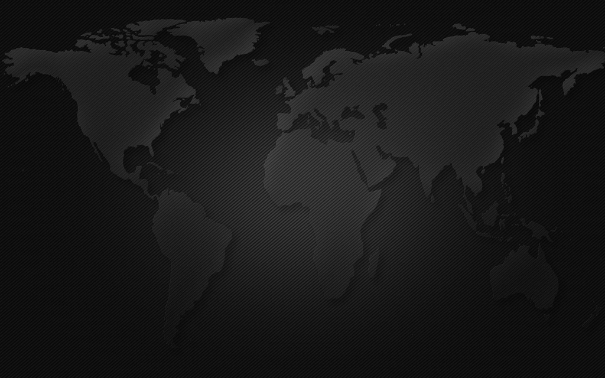

### Layer 2

Outline of countries or cities around the world with labelled names.

### Layer 3

Points corresponding to data centers and servers around the world. Something like this, but for the world:

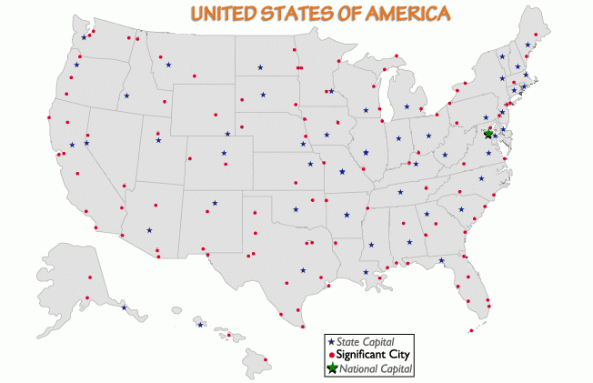

### Layer 4

Lines or arrows between servers that represent requests. A thicker or brighter line means more requests. The lines should cluster together when the zoom level is big enough for server points to cluster together. Something like this:

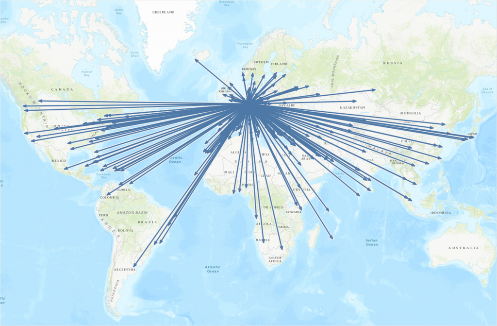

### Layer 5

A legend in the corner explaining the map and showing what the thicknesses / brightness corresponds to in terms of the number of requests.

## 3.

Your colleague has found some ruins during a hike in the Blue Mountains and recorded the coordinates of structures on her phone(RCFeature.csv). She would like to map her points but has no computer or mapping skills. Can you make a map that she can work with using only a browser? She needs an interactive map that she can download to her computer and use straightaway.

```r
library(leaflet)
library(tidyverse)
library(htmltools)
library(htmlwidgets)
```

```r
data_points <- read_csv('RCFeature.csv') # Read the data

map <- leaflet() %>%
  setView(lat = -33.7636569, lng = 150.2925029, zoom = 13) %>% # Look at Katoomba
  addProviderTiles('OpenTopoMap') %>% # Use this topography map
  addCircleMarkers( # Add circles on the data points
    radius = data_points$Accuracy, # Doesn't really work with clustering :(
    clusterOptions = markerClusterOptions(), # Good idea, since points are very condensed
    lng = data_points$Longitude, # Location of point
    lat = data_points$Latitude, # Location of point
    fillOpacity = 0.6, # Looks nicer, but only without clustering
    opacity = 0, # No line around the circle (only without clustering)
    popup = paste( # `label` will make hovering show data, but it will not display it nicely
      '<p><strong>FeatureType: </strong>', data_points$FeatureType, '</p>',
      '<p><strong>FeatureID: </strong>', data_points$FeatureID, '</p>',
      '<p><strong>Description: </strong>', data_points$Description, '</p>'
    )
  ) %>%
  addMiniMap(position = 'bottomright', tiles = 'OpenTopoMap') %>% # Shows where we are on a mini map
  addMeasure(position = 'bottomleft', primaryLengthUnit = 'meters', primaryAreaUnit = 'sqmeters') # Gives us tools to measure distances etc
```

```r
# Saves the map:
saveWidget(map, file="castle-ruins.html", selfcontained = TRUE)
```